# POP Parallel SS Model

```r
# remotes::install_github("r4ss/r4ss")
require(ggplot2)
require(r4ss)
require(dplyr)
require(here)
require(reshape2)
theme_set(theme_minimal())
```

```r
## load in derived quants from previous model for comparisons
mod21 <- read.csv(here('2023','data','output','2021_derived_quants.csv'))
mod21$value <- as.numeric(gsub(',','',mod21$value))
```

# Initial builds

Models 100.01 to .04 include all the data and the ageing error matrix. M and h are both fixed in the model but there is no prior.

```r
mod100_01 <- SS_output(here('2023','ss','v-100.04'))

SSplotData(mod100_01)
SSplotBiology(mod100_01, subplots = c(1,5,9))
SSplotIndices(mod100_01, subplots = 2)
SSplotTimeseries(mod100_01,subplot = 1)
SSplotTimeseries(mod100_01, subplot = 11)
SSplotRecdevs(mod100_01, subplots = 1)
SSplotComps(mod100_01,kind = 'LEN')
SSplotComps(mod100_01,kind = 'AGE')
SSplotSelex(mod100_01)

SSplotAgeMatrix(mod100_01, option =2 )

SSplotTimeseries(mod100_01,subplot = 7)
compdf<- mod100_01$timeseries%>% filter(Era == 'TIME')  %>% select(Yr, SpawnBio) %>%
  melt(., id = 'Yr') %>%
  mutate(source = 'SS mod') %>%
  bind_rows(., mod21 %>%
              filter(VARIABLE == 'SPAWNBIO') %>%
              select(Yr = YEAR, value ) %>%
              mutate(source = '2021 Assessment'))

ggplot(compdf, aes(x = Yr, y = value, color = source)) +
  geom_line()
```

Before tackling the prior & steepness issues I also want to get into selex. Realized there were some data wts on v100.04 so removed those. General philosophy is I am not trying to do a perfect bridge here; rather I am going to create something that seeems plausible, then can piecewise test major model differences (estimating q vs analyitcal, nat M, rec-dev treatment).

Selex at age. Length selex off.

Fish selex has four time blocks with varying functional forms. Survey selex is asymptotic and non time varying. I used a double normal and simply locked up the terminal values. Per the base par file, survey pars associated with “srv 1” are # a50_srv1: 5.39748301693 # delta_srv1: 5.72319662062 I used the SS selex excel sheet to eyeball this, then pasted the resultant par values and free only p1, p3. I updated the phases as well. The start-logit was bounded between 2 and 29 but this could theoretically get estimated.

```r
mod100_05 <- SS_output(here('2023','ss','v-100.05'))
SSplotSelex(mod100_05)
SS_plots(mod100_05)
```

Then I updated the WAA parameters and maturity parameters based on the last assessment. The age at 50% maturity is 9.5 None of these are estimated in the model. But all growth pars are; I also constrained the VB pars somewhat since the curve was discontinuous. I think the settlement age should be 2. The log_mean_rec in the original is 4.43, somehwat akin to R0, so updated that INIT

```r
mod100_06 <- SS_output(here('2023','ss','v-100.06'))
SSplotBiology(mod100_06, subplots = c(1))
SSplotBiology(mod100_06, subplots = c(5))
SSplotBiology(mod100_06, subplots = c(9))
SSplotSelex(mod100_06, subplots =4)
SS_plots(mod100_06)
```

For 100.07 I introduced time blocking for the fishery selex. This is done by introducing a line for each of four timeblocks x 3 estiamted pars per time block. For these guys I’m estimating ps 1,4,6 since we have true domes; none of these curves line up perfectly KIM the SS syntax is that we are assigning it block DESIGN 2 with block function 2 (replace with pars).

The selex doesn’t actually vary a ton across these blocks, and interestingly none want to actually do the dome.

```r
mod100_08 <- SS_output(here('2023','ss','v-100.08'))
SS_plots(mod100_08)
```

For mod_09 I switch q to be analytical and re-constrain R0 to be no more than 12. I also updated the prior information for M to icnlude the fishlife prior as a normal. Then I turn on estimation of M, fixing steepness at 0.95. To deal with some warnings I had to update some par bounds and update the age post settlement to 1. This is the first time the scale is in line between the models.

I also realized that the maturity p2 was supposed to be logged, so instead of 0.66 used -0.4 for the slope.

```
Parameter matching profile.string=NatM: NatM_uniform_Fem_GP_1
Parameter values (after subsetting based on input 'models'): 0.02, 0.03, 0.04, 0.05, 0.06, 0.07, 0.08, 0.09, 0.1, 0.11, 0.12, 0.13, 0.14, 0.15
Parameter prior likelihoods: 0.983275, 0.735139, 0.523022, 0.346924, 0.206846, 0.102786, 0.0347463, 0.00272523, 0.00672336, 0.0467407, 0.122777, 0.234833, 0.382908, 0.567002
Likelihood components showing max change as fraction of total change.
To change which components are included, change input 'minfraction'.
```

|  | frac_change | include | label |
| --- | --- | --- | --- |
| TOTAL | 1.0000 | TRUE | Total |
| Catch | 0.0000 | FALSE | Catch |
| Equil_catch | 0.0000 | FALSE | Equilibrium catch |
| Survey | 0.6346 | TRUE | Index data |
| Length_comp | 0.4513 | TRUE | Length data |
| Age_comp | 0.6111 | TRUE | Age data |
| Recruitment | 0.4394 | TRUE | Recruitment |
| InitEQ_Regime | 0.0000 | FALSE | Initital equilibrium recruitment |
| Forecast_Recruitment | 0.0000 | FALSE | Forecast recruitment |
| Parm_priors | 0.0114 | TRUE | Priors |

[output cut: 3 more lines]

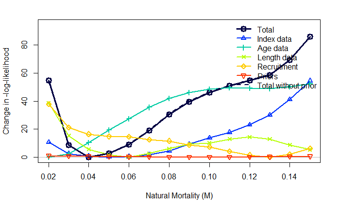

```r
 r4ss::SSplotProfile(profilesummary, # summary object
 profile.string = "NatM", # substring of profile parameter
profile.label = "Natural Mortality (M)",
plotdir = dir_prof, print = TRUE)
```

Need to ask Pete whether that whacky spike in the beginning is true for the 2021 model as well.

I want to investigate some behavior using this model. These include some CIE questions but I think the behavior is close enough we can compare. Separately, I set fleet to -1 for the early fishery length comps. This fits the survey slightly better but changes the mgmt status. Separately, I allow h to be estimated. This doesn’t change much. Separately, I start the model in 1975. This changes the scale drastically

```r
moddirs <- dir(here('2023','ss'), pattern =  '100.09', full.names = TRUE)[c(1,2,4)]
biglist <- lapply(moddirs, SS_output) %>% r4ss::SSsummarize()
SSplotComparisons(biglist, print = T, plotdir = here('2023','ss','v-100.09'), legendlabels =basename(moddirs))
```